# Clustering Analysis for Drilling Machine States

## 3. DBSCAN Clustering

### 3.1 Determine Optimal Epsilon using KNN Plot

DBSCAN requires two parameters: epsilon (eps) and minimum points (minPts). We’ll use a k-nearest neighbors distance plot to determine an appropriate eps value:

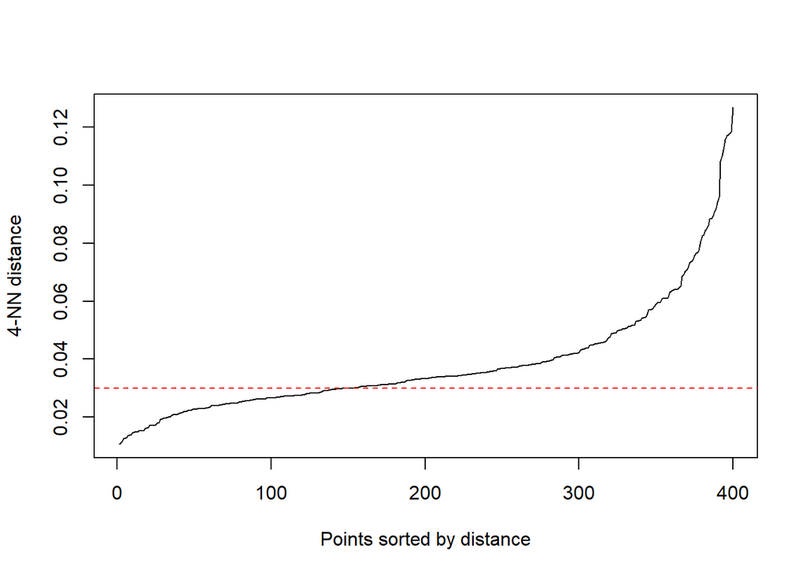

```r
kNNdistplot(select(drill, x, y), k = 4)
abline(h = 0.03, lty = 2, col = "red")
```

### 3.2 Apply DBSCAN and Visualize

DBSCAN has identified multiple clusters, with some points potentially classified as noise (cluster 0). The clustering pattern differs from K-means and hierarchical clustering, which might indicate that DBSCAN is detecting more fine-grained structure or treating some points as outliers.

Let’s try adjusting the eps parameter to see if we can get a clustering pattern more similar to the other methods:

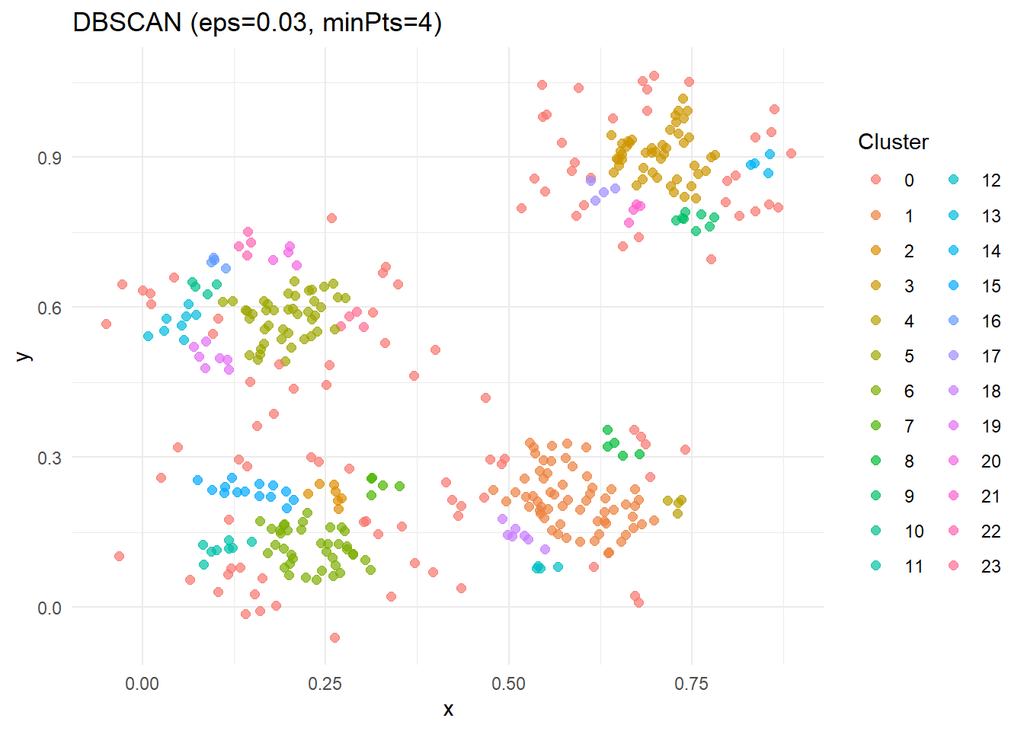

```r
# Apply DBSCAN (eps=0.03)
db1 <- dbscan(select(drill, x, y), eps = 0.03, minPts = 4)
drill$dbscan_cluster <- factor(db1$cluster)

# Visualize result
ggplot(drill, aes(x = x, y = y, color = dbscan_cluster)) +
  geom_point(size = 2, alpha = 0.7) +
  labs(title = "DBSCAN (eps=0.03, minPts=4)", color = "Cluster") +
  theme_minimal()
```

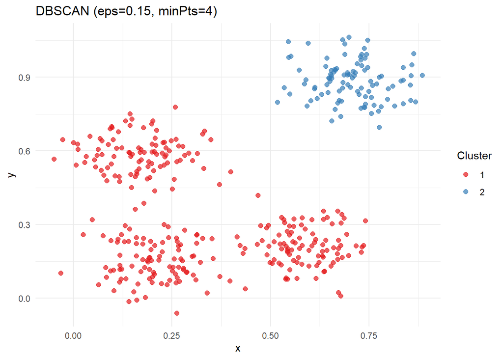

```r
# Adjust eps to 0.15 and reapply
db2 <- dbscan(select(drill, x, y), eps = 0.15, minPts = 4)
drill$dbscan_adjusted <- factor(db2$cluster)

# Visualize adjusted
ggplot(drill, aes(x = x, y = y, color = dbscan_adjusted)) +
  geom_point(size = 2, alpha = 0.7) +
  labs(title = "DBSCAN (eps=0.15, minPts=4)", color = "Cluster") +
  theme_minimal() +
  scale_color_brewer(palette = "Set1")
```

With an adjusted eps value, DBSCAN now identifies fewer clusters. This suggests that the machine’s operating states might have internal structure or variation that DBSCAN can detect with certain parameter settings.